# Danish Kings Homework Week 10

Sarah Astrup

7 March 2025

The task here is to load your Danish Monarchs csv into R using the `tidyverse` toolkit, calculate and explore the kings’ duration of reign with pipes `%>%` in `dplyr` and plot it over time.

## Load the kings

Make sure to first create an `.Rproj` workspace with a `data/` folder where you place either your own dataset or the provided `kings.csv` dataset.

1. Look at the dataset that are you loading and check what its columns are separated by? (hint: open it in plain text editor to see)

List what is the

separator: “,”

2. Create a `kings` object in R with the different functions below and inspect the different outputs.
- `read.csv()`
- `read_csv()`
- `read.csv2()`
- `read_csv2()`

```r
# FILL IN THE CODE BELOW and review the outputs
kings1 <- read.csv("data/kings.csv", na="NULL")
glimpse(kings1)
```

```
## Rows: 54
## Columns: 11
## $ Name       <chr> "Gorm den Gamle", "Harald 1. Blåtand", "Toke_Gormsen", "Sve…
## $ House      <chr> "Gorm", "Gorm", "Gorm", "Gorm", "Gorm", "Gorm", "Gorm", "Fa…
## $ Start_year <int> 936, NA, 985, NA, 1014, 1018, 1035, 1042, 1047, 1074, 1080,…
## $ End_year   <int> 958, NA, 986, NA, 1018, 1035, 1042, 1047, 1074, 1080, 1086,…
## $ Birth_year <int> 908, 936, NA, NA, 963, NA, 995, 1018, 1024, 1019, 1041, 104…
## $ Death_year <int> 958, 985, 986, 1014, NA, 1035, 1042, 1047, 1076, 1080, 1086…
## $ Gender     <chr> "M", "M ", "M ", "M ", "M ", "M ", "M ", "M ", "M ", "M ", …
## $ Dynasty    <chr> "Jellingdynastiet", "Jellingdynastiet", "Jellingdynastiet",…
## $ Source     <chr> "https://da.wikipedia.org/wiki/Gorm_den_Gamle", "https://da…
## $ BirthDMY   <chr> "908", "936", "", "17/04/963", "994", "995", "1018", "1024"…
## $ DeathDMY   <chr> "958", "987", "", "03/02/1014", "1018", "12/11/1035", "08/0…
```

```r
kings2 <- read_csv("data/kings.csv", na="NULL")
glimpse(kings2)
```

```
## Rows: 54
## Columns: 11
## $ Name       <chr> "Gorm den Gamle", "Harald 1. Blåtand", "Toke_Gormsen", "Sve…
## $ House      <chr> "Gorm", "Gorm", "Gorm", "Gorm", "Gorm", "Gorm", "Gorm", "Fa…
## $ Start_year <dbl> 936, NA, 985, NA, 1014, 1018, 1035, 1042, 1047, 1074, 1080,…
## $ End_year   <dbl> 958, NA, 986, NA, 1018, 1035, 1042, 1047, 1074, 1080, 1086,…
## $ Birth_year <dbl> 908, 936, NA, NA, 963, NA, 995, 1018, 1024, 1019, 1041, 104…
## $ Death_year <dbl> 958, 985, 986, 1014, NA, 1035, 1042, 1047, 1076, 1080, 1086…
## $ Gender     <chr> "M", "M", "M", "M", "M", "M", "M", "M", "M", "M", "M", "M",…
## $ Dynasty    <chr> "Jellingdynastiet", "Jellingdynastiet", "Jellingdynastiet",…
## $ Source     <chr> "https://da.wikipedia.org/wiki/Gorm_den_Gamle", "https://da…
## $ BirthDMY   <chr> "908", "936", "", "17/04/963", "994", "995", "1018", "1024"…
## $ DeathDMY   <chr> "958", "987", "", "03/02/1014", "1018", "12/11/1035", "08/0…
```

```r
kings3 <- read.csv2("data/kings.csv",  na="NULL")
glimpse(kings3)
```

```
## Rows: 56
## Columns: 1
## $ Name.House.Start_year.End_year.Birth_year.Death_year.Gender.Dynasty.Source.BirthDMY.DeathDMY <chr> …
```

```r
kings4 <- read_csv2( "data/kings.csv",  na="NULL")
```

```
## ℹ Using "','" as decimal and "'.'" as grouping mark. Use `read_delim()` for more control.
```

```r
glimpse(kings4)
```

```
## Rows: 54
## Columns: 1
## $ `Name,House,Start_year,End_year,Birth_year,Death_year,Gender,Dynasty,Source,BirthDMY,DeathDMY` <chr> …
```

Answer: 1. Which of these functions is a `tidyverse` function? Read data with it below into a `kings` object

Tidyverse is kings2 and kings4 which is downloaded into R. Kings1 and Kings3 are the original R or builded in R. CSV2 is used when the dataset is seperated by “;” and CSV is used when datasets are seperated by “,”

2. What is the result of running `class()` on the `kings` object created with a tidyverse function.

When running class on kings 2 and kings 4 it shows: [1] “spec_tbl_df” “tbl_df” “tbl” “data.frame, which describes a tibble

3. How many columns does the object have when created with these different functions?

The functions kings3 and kings4 has 1 column. The functions kings1 and kings2 have 11 columns.

4. Show the dataset so that we can see how R interprets each column

```r
# COMPLETE THE BLANKS BELOW WITH YOUR CODE, then turn the 'eval' flag in this chunk to TRUE.

kings <- read_csv("data/kings.csv", na="NULL")
class(kings)
```

```
## [1] "spec_tbl_df" "tbl_df"      "tbl"         "data.frame"
```

```r
ncol(kings)
```

```
## [1] 11
```

```r
glimpse(kings)
```

```
## Rows: 54
## Columns: 11
## $ Name       <chr> "Gorm den Gamle", "Harald 1. Blåtand", "Toke_Gormsen", "Sve…
## $ House      <chr> "Gorm", "Gorm", "Gorm", "Gorm", "Gorm", "Gorm", "Gorm", "Fa…
## $ Start_year <dbl> 936, NA, 985, NA, 1014, 1018, 1035, 1042, 1047, 1074, 1080,…
## $ End_year   <dbl> 958, NA, 986, NA, 1018, 1035, 1042, 1047, 1074, 1080, 1086,…
## $ Birth_year <dbl> 908, 936, NA, NA, 963, NA, 995, 1018, 1024, 1019, 1041, 104…
## $ Death_year <dbl> 958, 985, 986, 1014, NA, 1035, 1042, 1047, 1076, 1080, 1086…
## $ Gender     <chr> "M", "M", "M", "M", "M", "M", "M", "M", "M", "M", "M", "M",…
## $ Dynasty    <chr> "Jellingdynastiet", "Jellingdynastiet", "Jellingdynastiet",…
## $ Source     <chr> "https://da.wikipedia.org/wiki/Gorm_den_Gamle", "https://da…
## $ BirthDMY   <chr> "908", "936", "", "17/04/963", "994", "995", "1018", "1024"…
## $ DeathDMY   <chr> "958", "987", "", "03/02/1014", "1018", "12/11/1035", "08/0…
```

## Calculate the duration of reign for all the kings in your table

You can calculate the duration of reign in years with `mutate` function by subtracting the equivalents of your `startReign` from `endReign` columns and writing the result to a new column called `duration`. But first you need to check a few things:

- Is your data messy? Fix it before re-importing to R
- Do your start and end of reign columns contain NAs? Choose the right strategy to deal with them: `na.omit()`, `na.rm=TRUE`, `!is.na()`

Create a new column called `duration` in the kings dataset, utilizing the `mutate()` function from tidyverse. Check with your group to brainstorm the options.

```r
kings_duration <- kings %>%
  mutate(duration = End_year-Start_year) %>%
  mutate(midyear = Start_year + (End_year-Start_year)/2) %>%
  na.omit(duration)

# We use the mutate() function and na.omit to remove the missing values

glimpse(kings_duration)
```

```
## Rows: 47
## Columns: 13
## $ Name       <chr> "Gorm den Gamle", "Hardeknud", "Magnus den Gode", "Svend 2.…
## $ House      <chr> "Gorm", "Gorm", "Fairhair", "Estridsen", "Estridsen", "Estr…
## $ Start_year <dbl> 936, 1035, 1042, 1047, 1074, 1080, 1086, 1095, 1104, 1134, …
## $ End_year   <dbl> 958, 1042, 1047, 1074, 1080, 1086, 1095, 1103, 1134, 1137, …
## $ Birth_year <dbl> 908, 995, 1018, 1024, 1019, 1041, 1043, 1050, 1055, 1065, 1…
## $ Death_year <dbl> 958, 1042, 1047, 1076, 1080, 1086, 1095, 1103, 1134, 1137, …
## $ Gender     <chr> "M", "M", "M", "M", "M", "M", "M", "M", "M", "M", "M", "M",…
## $ Dynasty    <chr> "Jellingdynastiet", "Jellingdynastiet", "Jellingdynastiet",…
## $ Source     <chr> "https://da.wikipedia.org/wiki/Gorm_den_Gamle", "https://da…
## $ BirthDMY   <chr> "908", "1018", "1024", "1019", "1041", "1043", "1050", "105…
## $ DeathDMY   <chr> "958", "08/06/1042", "25/10/1047", "28/04/1076", "17/04/108…
## $ duration   <dbl> 22, 7, 5, 27, 6, 6, 9, 8, 30, 3, 9, 25, 20, 39, 9, 2, 7, 27…
## $ midyear    <dbl> 947.0, 1038.5, 1044.5, 1060.5, 1077.0, 1083.0, 1090.5, 1099…
```

## Calculate the average duration of reign for all rulers

Do you remember how to calculate an average on a vector object? If not, review the last two lessons and remember that a column is basically a vector. So you need to subset your `kings` dataset to the `duration` column. If you subset it as a vector you can calculate average on it with `mean()` base-R function. If you subset it as a tibble, you can calculate average on it with `summarize()` tidyverse function. Try both ways!

- You first need to know how to select the relevant `duration` column. What are your options?
- Is your selected `duration` column a tibble or a vector? The `mean()` function can only be run on a vector. The `summarize()` function works on a tibble.
- Are you getting an error that there are characters in your column? Coerce your data to numbers with `as.numeric()`.
- Remember to handle NAs: `mean(X, na.rm=TRUE)`

```r
kings_average <- mean(kings_duration$duration, na.rm = TRUE)

kings_average
```

```
## [1] 19.87234
```

```r
#the summarize function didn't work so we use mean() and make it a vector with kings_duration$duration
```

## How many and which kings enjoyed a longer-than-average duration of reign?

You have calculated the average duration above. Use it now to `filter()` the `duration` column in `kings` dataset. Display the result and also count the resulting rows with `count()`

```r
 duration_above_average <- kings_duration %>%
  filter(duration>20)

glimpse(duration_above_average)
```

```
## Rows: 22
## Columns: 13
## $ Name       <chr> "Gorm den Gamle", "Svend 2. Estridsen", "Niels", "Valdemar …
## $ House      <chr> "Gorm", "Estridsen", "Estridsen", "Estridsen", "Estridsen",…
## $ Start_year <dbl> 936, 1047, 1104, 1157, 1202, 1259, 1286, 1340, 1396, 1448, …
## $ End_year   <dbl> 958, 1074, 1134, 1182, 1241, 1286, 1319, 1375, 1439, 1481, …
## $ Birth_year <dbl> 908, 1024, 1055, 1131, 1170, 1249, 1274, 1320, 1382, 1426, …
## $ Death_year <dbl> 958, 1076, 1134, 1182, 1241, 1286, 1319, 1375, 1459, 1481, …
## $ Gender     <chr> "M", "M", "M", "M", "M", "M", "M", "M", "M", "M", "M", "M",…
## $ Dynasty    <chr> "Jellingdynastiet", "", "Jellingdynastiet", "Jellingdynasti…
## $ Source     <chr> "https://da.wikipedia.org/wiki/Gorm_den_Gamle", "https://da…
## $ BirthDMY   <chr> "908", "1019", "1134", "14/01/1131", "05/1170", "1249", "12…
## $ DeathDMY   <chr> "958", "28/04/1076", "25/06/1134", "12/05/1182", "28/03/124…
## $ duration   <dbl> 22, 27, 30, 25, 39, 27, 33, 35, 43, 33, 31, 23, 29, 60, 22,…
## $ midyear    <dbl> 947.0, 1060.5, 1119.0, 1169.5, 1221.5, 1272.5, 1302.5, 1357…
```

```r
count(duration_above_average, sort = TRUE)
```

```
## # A tibble: 1 × 1
##       n
##   <int>
## 1    22
```

## How many days did the three longest-ruling monarchs rule?

- Sort kings by reign `duration` in the descending order. Select the three longest-ruling monarchs with the `slice()` function
- Use `mutate()` to create `Days` column where you calculate the total number of days they ruled
- BONUS: consider the transition year (with 366 days) in your calculation!

```r
duration_descending <- kings_duration %>%
  arrange(desc(duration))

glimpse(duration_descending)
```

```
## Rows: 47
## Columns: 13
## $ Name       <chr> "Christian 4.", "Erik 7. af Pommern", "Christian 9.", "Chri…
## $ House      <chr> "Oldenburg", "Pomerania", "Schleswig-Holstein-Sonderburg-Gl…
## $ Start_year <dbl> 1588, 1396, 1863, 1766, 1202, 1340, 1912, 1286, 1448, 1482,…
## $ End_year   <dbl> 1648, 1439, 1906, 1808, 1241, 1375, 1947, 1319, 1481, 1513,…
## $ Birth_year <dbl> 1577, 1382, 1818, 1749, 1170, 1320, 1870, 1274, 1426, 1455,…
## $ Death_year <dbl> 1648, 1459, 1906, 1808, 1241, 1375, 1947, 1319, 1481, 1513,…
## $ Gender     <chr> "M", "M", "M", "M", "M", "M", "M", "M", "M", "M", "M", "M",…
## $ Dynasty    <chr> "Oldenborg", "Jellingdynastiet", "Glücksborg", "Oldenborg",…
## $ Source     <chr> "https://da.wikipedia.org/wiki/Christian_4.", "https://da.w…
## $ BirthDMY   <chr> "12/04/1577", "1382", "08/04/1818", "29/01/1749", "05/1170"…
## $ DeathDMY   <chr> "28/02/1648", "24/09/1459", "29/1/1906", "13/03/1808", "28/…
## $ duration   <dbl> 60, 43, 43, 42, 39, 35, 35, 33, 33, 31, 31, 31, 30, 29, 29,…
## $ midyear    <dbl> 1618.0, 1417.5, 1884.5, 1787.0, 1221.5, 1357.5, 1929.5, 130…
```

```r
#Calculating the longest reign
longest_reign <- duration_descending %>%
  slice(c(1,2,3))

longest_reign
```

```
## # A tibble: 3 × 13
##   Name     House Start_year End_year Birth_year Death_year Gender Dynasty Source
##   <chr>    <chr>      <dbl>    <dbl>      <dbl>      <dbl> <chr>  <chr>   <chr>
## 1 Christi… Olde…       1588     1648       1577       1648 M      Oldenb… https…
## 2 Erik 7.… Pome…       1396     1439       1382       1459 M      Jellin… https…
## 3 Christi… Schl…       1863     1906       1818       1906 M      Glücks… https…
## # ℹ 4 more variables: BirthDMY <chr>, DeathDMY <chr>, duration <dbl>,
## #   midyear <dbl>
```

```r
#Calculating days
reign_days <- longest_reign %>%
  mutate(days=duration*365)

glimpse(reign_days)
```

```
## Rows: 3
## Columns: 14
## $ Name       <chr> "Christian 4.", "Erik 7. af Pommern", "Christian 9."
## $ House      <chr> "Oldenburg", "Pomerania", "Schleswig-Holstein-Sonderburg-Gl…
## $ Start_year <dbl> 1588, 1396, 1863
## $ End_year   <dbl> 1648, 1439, 1906
## $ Birth_year <dbl> 1577, 1382, 1818
## $ Death_year <dbl> 1648, 1459, 1906
## $ Gender     <chr> "M", "M", "M"
## $ Dynasty    <chr> "Oldenborg", "Jellingdynastiet", "Glücksborg"
## $ Source     <chr> "https://da.wikipedia.org/wiki/Christian_4.", "https://da.w…
## $ BirthDMY   <chr> "12/04/1577", "1382", "08/04/1818"
## $ DeathDMY   <chr> "28/02/1648", "24/09/1459", "29/1/1906"
## $ duration   <dbl> 60, 43, 43
## $ midyear    <dbl> 1618.0, 1417.5, 1884.5
## $ days       <dbl> 21900, 15695, 15695
```

## Challenge: Plot the kings’ duration of reign through time

What is the long-term trend in the duration of reign among Danish monarchs? How does it relate to the historical violence trends ?

- Try to plot the duration of reign column in `ggplot` with `geom_point()` and `geom_smooth()`
- In order to peg the duration (which is between 1-99) somewhere to the x axis with individual centuries, I recommend creating a new column `midyear` by adding to `startYear` the product of `endYear` minus the `startYear` divided by two (`startYear + (endYear-startYear)/2`).
- Now you can plot the kings dataset, plotting `midyear` along the x axis and `duration` along y axis
- BONUS: add a title, nice axis labels to the plot and make the theme B&W and font bigger to make it nice and legible!

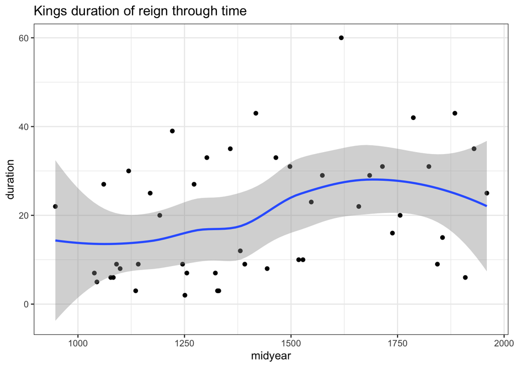

```r
# midyear is mutated in colon 83
kings_duration %>%
  ggplot(aes(x=midyear, y=duration))+
  geom_point()+
  geom_smooth()+
  theme_bw()+
  ggtitle("Kings duration of reign through time")
```

And to submit this rmarkdown, knit it into html. But first, clean up the code chunks, adjust the date, rename the author and change the `eval=FALSE` flag to `eval=TRUE` so your script actually generates an output. Well done!